# Case OnCase

Load libraries

```r
dir = 'C:/Projects/case_oncase/case_oncase'
setwd(dir)
library(tidyverse)
library(jsonlite)
library(ggthemes)
library(httr)
library(gridExtra)
library(mlr)
options(warn=-1)
```

Load the database

```r
recipesJson = stream_in(file('receitas.json'))
```

```
opening file input connection.
incomplete final line found on 'receitas.json'
```

```
 Found 1 records...
 Imported 1 records. Simplifying...
```

```
closing file input connection.
```

```r
recipes = as_tibble(recipesJson)
```

Remove duplicated data, outliers, data with missing values

```r
recipes = recipes[!duplicated(recipes[,c('title', 'desc', 'date')]),]
recipes$date = as.Date(recipes$date)
recipes$numOfIngredients = lengths(recipes$ingredients)
recipes$numOfDirections = lengths(recipes$directions)
recipes = recipes %>%
  filter(lengths(categories) > 0) %>%
  filter(!is.na(calories)) %>%
  filter(calories < sd(calories, na.rm=TRUE) * 3)
```

# 1. Which categories belong to the most caloric foods?

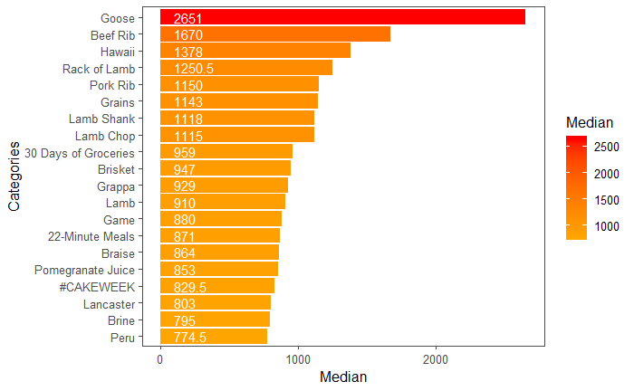

```r
rankCalories = recipes %>%
  unnest(categories) %>%
  group_by(categories) %>%
  summarise(Median = median(calories), Count = n()) %>%
  arrange(desc(Median)) %>%
  filter(Count > 1) %>%
  top_n(20, Median)

ggplot(rankCalories, aes(x = reorder(categories, Median),
  y = Median, fill = Median)) +
  geom_bar(stat='identity') +
  geom_text(aes(x = categories, y = 100, label = Median), hjust=0, colour = 'white') +
  labs(x = 'Categories') +
  coord_flip() +
  scale_fill_continuous(low="orange", high="red") +
  theme_few()
```

# 2. What are the top 10 ingredients contained in the most calorie recipes?

```r
rankCalories = recipes %>%
  unnest(ingredients) %>%
  group_by(ingredients) %>%
  summarise(Median = median(calories), Count = n()) %>%
  arrange(desc(Median)) %>%
  top_n(10, Median)
rankCalories %>% select('ingredients')
```

| ingredients |
| --- |
| 1 1/4 cups reduced-sodium chicken broth or water |
| 2 tablespoons harissa (spicy North African condiment) |
| Accompaniment: harissa or hot sauce |
| 1 1/4 teaspoons fennel seeds |
| 1 1/4 teaspoons ground coriander |
| 24 rib lamb chops (about 3/4 inch thick; 4 1/2 to 5 pounds total), frenched if desired |
| Accompaniment: Avocado Salsa and corn tortilla chips |
| 1 teaspoon (generous) ground allspice |
| 12 3- to 4-inch-long meaty short ribs (about 5 1/2 pounds), top membrane trimmed |
| Chopped celery leaves |

# 3. If you had to recommend 3 recipes based on the data, what would they be?

Depending on the client profile:

- Healthy
- Quick and easy
- Lunch/Breakfast/Dinner

A recommendation for me:

- Balanced amount of calories;
- Sodium intake below daily recommended (2000);
- Amount of protein above the median;
- Rating in the best quantile;
- Less than 5 ingredients for preparation;
- Removed drinks.

```r
rankRating = recipes %>%
  filter(calories >= median(calories)/1.5
         & calories <= median(calories) * 1.5
         & sodium < 2000
         & protein >= 9
         & lengths(ingredients) < 5
         & !str_detect(categories, 'Drink')
         & rating >= 4.38)
rankRating = rankRating %>%
  arrange(desc(protein), numOfDirections) %>%
  select('title','numOfIngredients', 'numOfDirections', 'protein', 'calories', 'fat')
rankRating[1:3, ]
```

| title | numOfIngredients | numOfDirections | protein | calories | fat |
| --- | --- | --- | --- | --- | --- |
| Grilled Striped Bass | 2 | 2 | 75 | 412 | 10 |
| Toasted Salted Pumpkin Seeds | 2 | 1 | 13 | 260 | 23 |
| Egg Noodles with Brown Butter and Feta | 3 | 3 | 11 | 376 | 19 |

# 4. Does any feature present in the data determine the high grade of a recipe?

- The more detailed/explained the recipe, better is the rating.

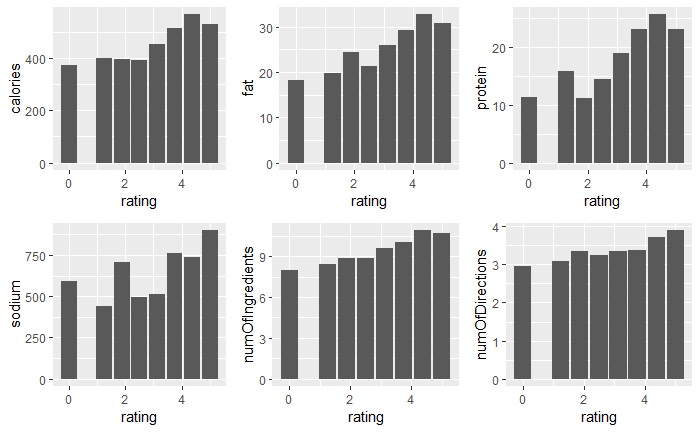

```r
plotCalories = ggplot(recipes, aes(x = rating, y = calories)) +
  geom_bar(stat = "summary", fun.y = "mean")
plotFat = ggplot(recipes, aes(x = rating, y = fat)) +
  geom_bar(stat = "summary", fun.y = "mean")
plotProtein = ggplot(recipes, aes(x = rating, y = protein)) +
  geom_bar(stat = "summary", fun.y = "mean")
plotSodium = ggplot(recipes, aes(x = rating, y = sodium)) +
  geom_bar(stat = "summary", fun.y = "mean")
plotIngredients = ggplot(recipes, aes(x = rating, y = numOfIngredients)) +
  geom_bar(stat = "summary", fun.y = "mean")
plotDirections = ggplot(recipes, aes(x = rating, y = numOfDirections)) +
  geom_bar(stat = "summary", fun.y = "mean")
grid.arrange(plotCalories, plotFat, plotProtein, plotSodium, plotIngredients, plotDirections, ncol=3)
```

# 5. Considering the categories of the top 100 recipes under review, how many recipes are currently on the site https://www.epicurious.com for each category

```r
removeAccent = function(str){
  symbols = c(acute = 'áéíóúÁÉÍÓÚýÝ', grave = 'àèìòùÀÈÌÒÙ', circunflex = 'âêîôûÂÊÎÔÛ',
      tilde = 'ãõÃÕñÑ', umlaut = 'äëïöüÄËÏÖÜÿ', cedil = 'çÇ')

  nudeSymbols = c(acute = 'aeiouAEIOUyY',grave = 'aeiouAEIOU',circunflex = 'aeiouAEIOU',
      tilde = 'aoAOnN',umlaut = 'aeiouAEIOUy',cedil = 'cC')

  punct = c(',', '\\.', '\\?', '-', ':', ';', '/')
  for (i in 1:length(punct)){
      str = gsub(punct[i], ' ', str)
  }
  punct = c('\'', '&', '+', '#', '\uFFFD')
  for (i in 1:length(punct)){
      str = gsub(punct[i], '', str)
  }
  return(chartr(paste(symbols, collapse = ''), paste(nudeSymbols, collapse = ''), str))
}
searchByCategory = function(category){
  category = removeAccent(category)
  category = gsub(' ', '%20', category)
  content = GET(paste0('https://www.epicurious.com/search/', category))
  startIndex = str_locate(content,'<span class="matching-count" data-reactid="39">')[2] + 1
  filteredContent1 = substring(content, startIndex)

  endIndex = str_locate(filteredContent1,'</span>')[1] - 1
  text = substring(filteredContent1, 0, endIndex)
  count = as.numeric(gsub(',', '', text))
  return (count)
}
topRecipesByRating = recipes %>%
  arrange(desc(rating))
topRecipesByRating = topRecipesByRating[1:100,]
categories = topRecipesByRating %>%
  select('categories') %>%
  unnest(categories)
categories = categories[!duplicated(categories),]
#Uncoment to run the search
#categories$count = sapply(categories$categories, searchByCategory)
#saveRDS(categories, 'categories.rds')
categories <- readRDS('categories.rds')
categories %>% arrange (desc(count))
```

| categories | count |
| --- | --- |
| Peanut | 17616 |
| Peanut Free | 17178 |
| Soy Free | 16792 |
| Nut | 16376 |
| Bon Appétit | 15900 |
| Tree Nut Free | 14408 |
| Vegetarian | 14337 |
| Kosher | 13049 |
| Pescatarian | 12529 |
| Gourmet | 11851 |

[output cut: 259 more lines]

# 6. Build a classifier to recommend tags (categories) for recipes:

- We have a multilabel classification problem, we need to train a classifier for each label.

```r
removeSpace = function(str){
  return (gsub(' ', '', str))
}
removeNumbers = function(str){
  numbers = '0123456789'
  return(removeSpace(chartr(numbers, paste(rep(' ', nchar(numbers)), collapse = ''), str)))
}
# Prepare the dataset
recipesSample = recipes[sample(nrow(recipes), 1000), ]
recipesSample$categoriesUpper = NA
recipesSample$categoriesUpper = lapply(recipesSample$categories, toupper)
recipesSample$categoriesUpper = lapply(recipesSample$categoriesUpper, removeAccent)
recipesSample$categoriesUpper = lapply(recipesSample$categoriesUpper, removeNumbers)
labels = recipesSample %>%
  select('categoriesUpper') %>%
  unnest(categoriesUpper)
# Select categories with at least 10 recipes
labels = labels %>% add_count(categoriesUpper) %>% filter(n >= 10) %>% select('categoriesUpper')
labels = labels[!duplicated(labels$categoriesUpper),]
labels = labels$categoriesUpper
df = data.frame(matrix(ncol = length(labels), nrow = 0))
names(df) = labels
for(i in 1:nrow(recipesSample)){
   for(j in 1:length(labels)){
       df[i, j] = str_detect(string = recipesSample$categoriesUpper[i], pattern = labels[[j]])
   }
}
recipesSample = recipesSample %>%
  select('fat', 'calories', 'protein', 'rating', 'sodium', 'numOfIngredients', 'numOfDirections')
data = cbind(recipesSample, df)
```

Start the predictions

```r
# Start the prediction task
task = makeMultilabelTask(data = data, target = unlist(labels))
n = getTaskSize(task)
train.set = sample(n, round(n * 0.75))
test.set = which(!(1:n %in% train.set))
binary.learner = makeLearner("classif.rpart", predict.type = "prob")
lrn = list()
lrn[[1]] = makeMultilabelBinaryRelevanceWrapper(binary.learner)
lrn[[2]] = makeMultilabelClassifierChainsWrapper(binary.learner)
lrn[[3]] = makeMultilabelDBRWrapper(binary.learner)
model = list()
prediction = list()
model[[1]] = train(lrn[[1]], task, subset = train.set)
prediction[[1]] = predict(model[[1]], task = task, subset = test.set)
model[[2]] = train(lrn[[2]], task, subset = train.set)
prediction[[2]] = predict(model[[2]], task = task, subset = test.set)
model[[3]] = train(lrn[[3]], task, subset = train.set)
prediction[[3]] = predict(model[[3]], task = task, subset = test.set)
perf = c()
# Overall performance
perf[1] = performance(prediction[[1]], measures = list(multilabel.acc))
perf[2] = performance(prediction[[2]], measures = list(multilabel.acc))
perf[3] = performance(prediction[[3]], measures = list(multilabel.acc))
best.index = which.max(perf)
best.model = model[[best.index]]
best.prediction = prediction[[best.index]]
best.perf = perf[best.index]
```

Show a sample result

|  | truth | response |
| --- | --- | --- |
| COCKTAIL | X | X |
| PARTY | X | X |
| COCKTAILPARTY | X |  |
| GIN | X | X |
| ALCOHOLIC | X | X |
| HOUSEGARDEN | X |  |
| DRINK | X | X |
| WINE | X |  |